# Pilot-Priming Non Maximality

Mora Maldonado

2 November 2015

## Design

#### Studies

| Condition | Study 1 (CCBC) | Study 2 (DDBD) |
| --- | --- | --- |
| Env-T | Collective | Distributive |
| Env-F | Collective | Distributive |
| Target 1 | Baseline | Baseline |
| Target 2 | Collective | Distributive |

*Next studies*

| Condition | Study 3 (BBBC) | Study 4 (BBBD) | Study 5 (CCCD) | Study 6 (CCXD) |
| --- | --- | --- | --- | --- |
| Env-T | Baseline | Baseline | Collective | Collective |
| Env-F | Baseline | Baseline | Collective | Collective |
| Target 1 | Baseline | Baseline | Collective | X |
| Target 2 | Collective | Distributive | Distributive | Distributive |

#### Groups

[link to the google sheet](https://docs.google.com/spreadsheets/d/1ngcopbwjqS_FTYbR3xhqaRAfzc2gM3yry8l5xu-YnVU/edit?usp=sharing)

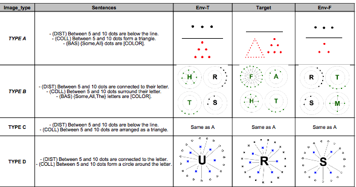

## Charging everything

#### Requiered packages

#### Charging subjects information

#### Charging the results

#### Ordering data

## Exploratory data

#### *Information on my data*

```r
kable(table(Info$study, Info$group), caption = "Number of subjects per group")
```

Number of subjects per group

| AB | BA | CD | DC |
| --- | --- | --- | --- |
| 5 | 5 | 5 | 5 |
| 5 | 5 | 5 | 5 |

```r
# kable(table(Results$study,Results$group)) str(Results)
```

#### Checking everything…

### Exploring distribution and subject variability

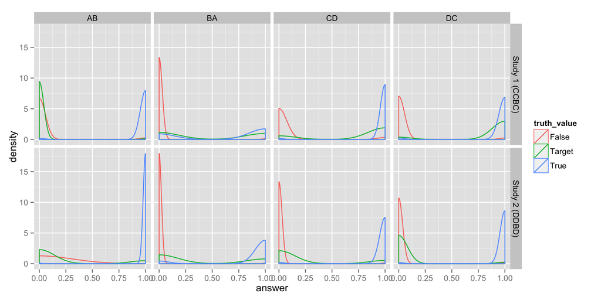

#### **plotting** variability

*Each line corresponds to a subject in the three different expected truth-values (Fillers and Experimental items are aggregated; Target == Target2)* Note: The two different patterns of results (specially in Study 1) might be related with the differences between image-predicate pairs (we are aggregating by group here)

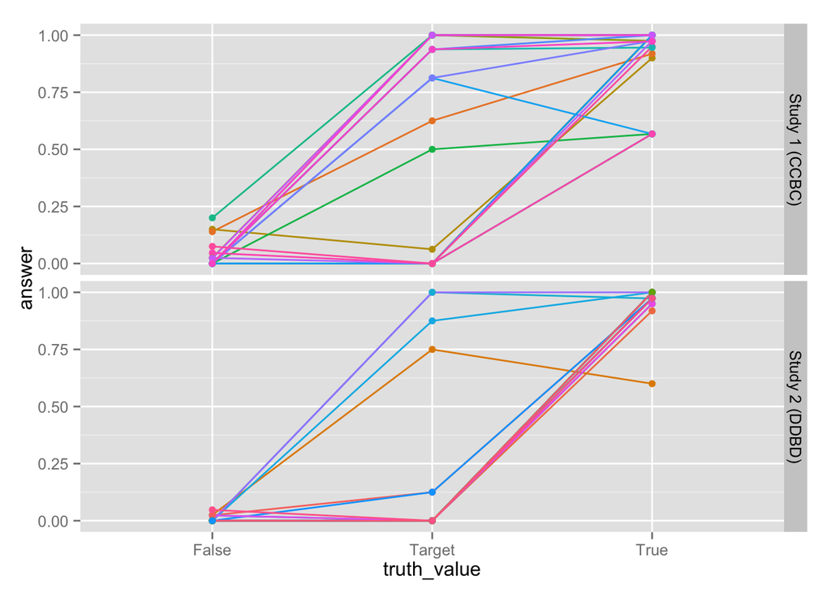

### Exploring RT

```
##    Min. 1st Qu.  Median    Mean 3rd Qu.    Max.
##     326    1188    1800    3537    3093 1029000
```

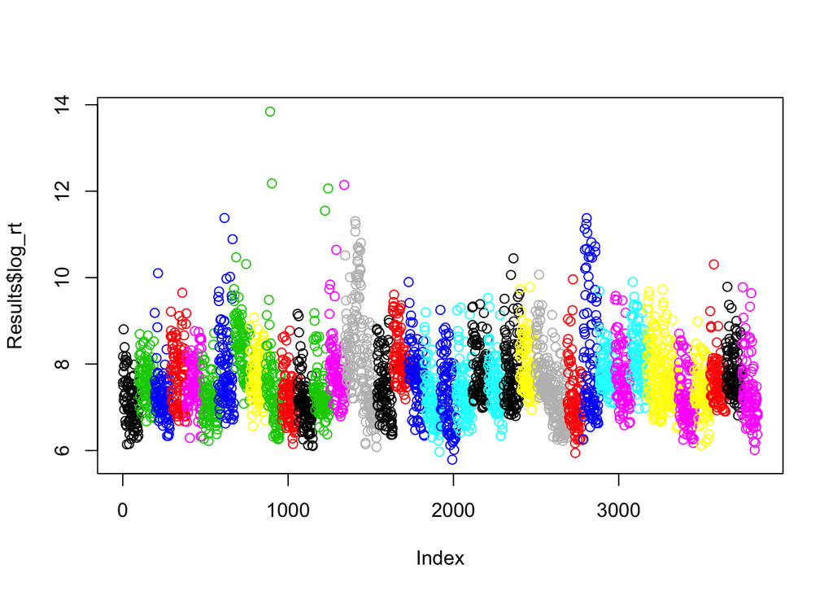

### Exclusion criteria

1. Not English speakers
2. RT +/- 2 sd from mean
3. - of 85 correct in fillers

**All subjects were accurate. Some trials were pretty slow but I didn’t take them out because we don’t have many subjects and they didn’t change the tendency**

### Fillers analysis

Are people paying attention?

#### **plotting** Fillers in bars

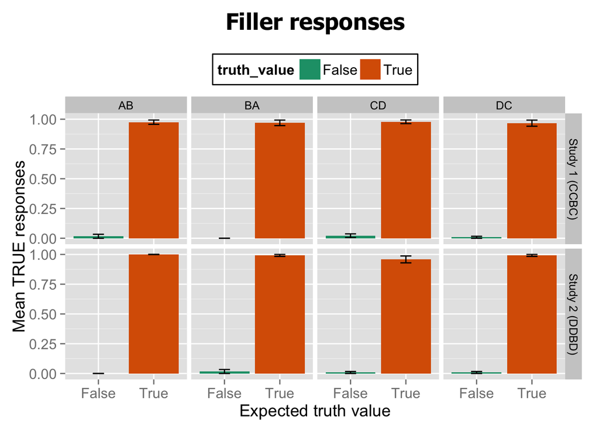

## Experimental items analysis

> Questions
1. Within Study 1
- Does collective predicates give rise to non-maximal readings? Study 1: **Target2 vs. Env-F**
- What is the relation between maximal and non-maximal readings? Study 1: **Target2 vs. Env-T**
2. Within Study 2
- How unlikely are non-maximal readings for distributive predicates? Study 2: **Target2 vs. Env-T**
- Are there phantom non-maximal readings for distributive predicates? (Replication of Marty et al. 2014 results) **Target2 vs. Env-F**
3. Are there fewer non-maximal readings for distributive than for collective predicates? **Interaction between Studies 1 and 2**

### 1. Response rate: Study X Condition

*Collapsing all the groups of subjects

> Aggregate data

| condition | study | response | se |
| --- | --- | --- | --- |
| Env-F | Study 1 (CCBC) | 0.07 | 0.03 |
| Env-F | Study 2 (DDBD) | 0.01 | 0.01 |
| Env-T | Study 1 (CCBC) | 0.79 | 0.09 |
| Env-T | Study 2 (DDBD) | 0.93 | 0.05 |
| Target1 | Study 1 (CCBC) | 0.50 | 0.01 |
| Target1 | Study 2 (DDBD) | 0.50 | 0.00 |
| Target2 | Study 1 (CCBC) | 0.53 | 0.10 |
| Target2 | Study 2 (DDBD) | 0.19 | 0.08 |

> *plotting*

Note: Target 1 = Baseline (50/50 of True/False)

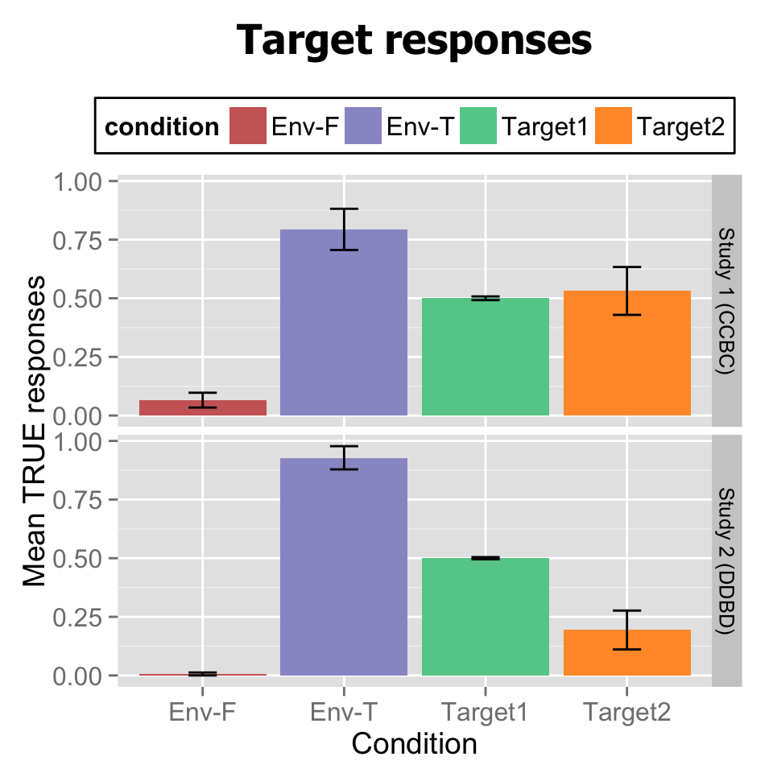

seen in another way….

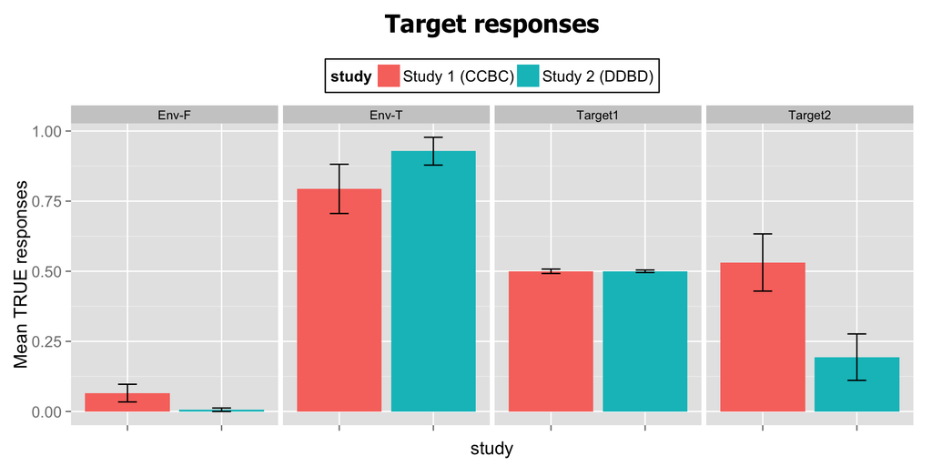

> Differences only for Target2

> Trials with image_type A and C have the same image but different predicate (form a square vs. arranged as a square)

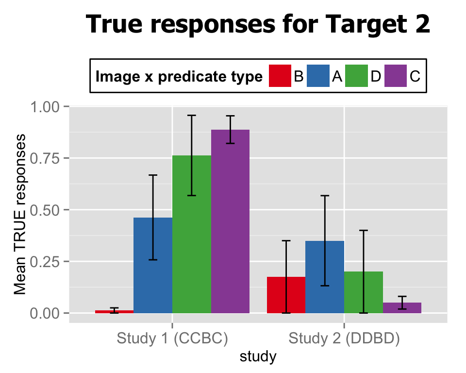

| predicate | A | B | C | D |
| --- | --- | --- | --- | --- |
| collective | form a square/triangle | surround their letter | arranged as a square/triangle | form a circle around the letter |
| distributive | are above/below the letter | are connected to their letter | are above/below the letter | are connected to the letter |

### Stats

*Global model*

```r
#I am taking out Target 1 because they are Baselines
mydata <- subset(Exp_Items, condition!='Target1')

#coding the interactions as factors
mydata$interaction<-contrasts(mydata$condition)[mydata$condition]*
contrasts(mydata$study)[mydata$study]

#### main model
m1 <- glmer(answer~condition+study+interaction+(1+condition|subject), mydata, family=binomial)
summary(m1)

#NOTE: I am not sure here how to code groups (I have to?)
```

*1. Main effect of condition in BOTH experiments*

```r
m0 <- glmer(answer~study+interaction+(1+condition|subject), mydata, family=binomial)
summary(anova(m1,m0))
```

*2. Main effect of experiments*

```r
m0 <- glmer(answer~condition+interaction+(1+condition|subject), mydata, family=binomial)
summary(anova(m1,m0))
```

*3. Interaction*

```r
m0 <- glmer(answer~condition+study+(1+condition|subject), mydata, family=binomial)
summary(anova(m1,m0))
```

*4. effect of Group?* Not sure about this-

```r
m1 <- glmer(answer~condition+study+group+interaction+(1+condition|subject), mydata, family=binomial)
m0 <- glmer(answer~condition+study+interaction+(1+condition|subject), mydata, family=binomial)
summary(anova(m1,m0))
```

**If there is an interaction, I repeat step (1) for each experiment.**

### 2. Response rate: Study X Group X Condition

*Checking for effects of the group (~image)*

> Aggregate data

> *plotting*

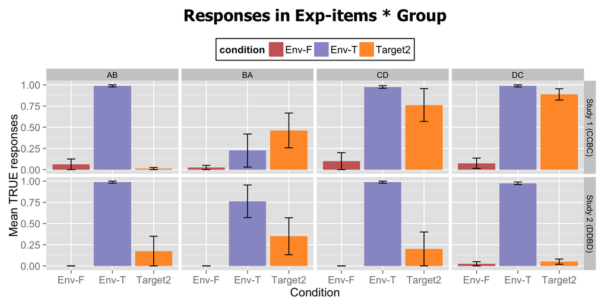

### 3. Response times: Study X Condition

> Aggregate data

> *plotting*

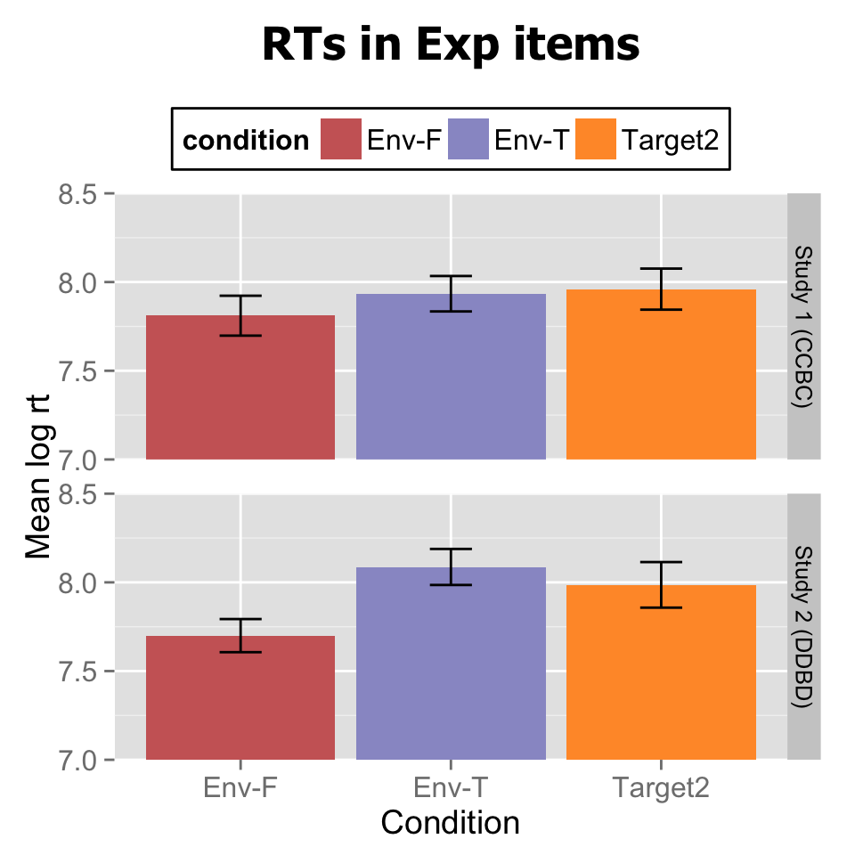

##### Only TRUE cases

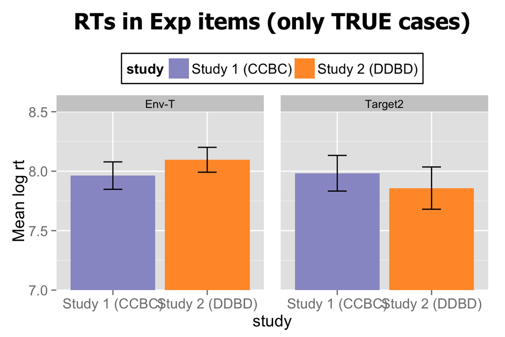

### 4. Response times: Study X Condition X Group

> Aggregate data

I am taking out Target1 because the type of sentence is different.

> *plotting*

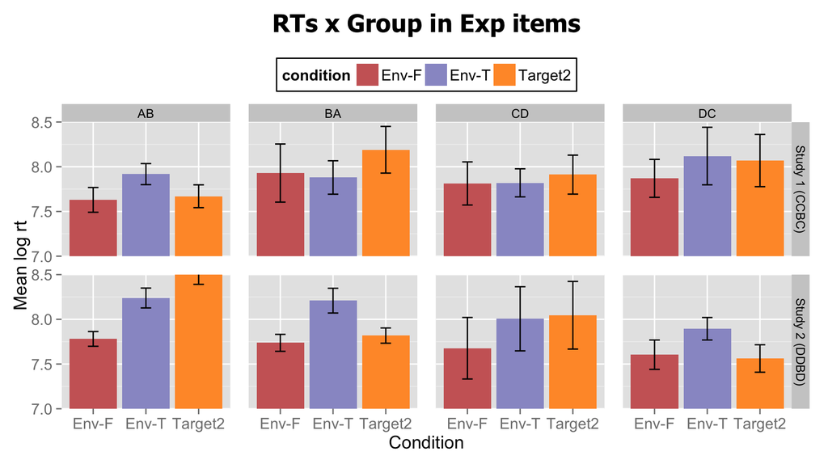

##### Only TRUE cases

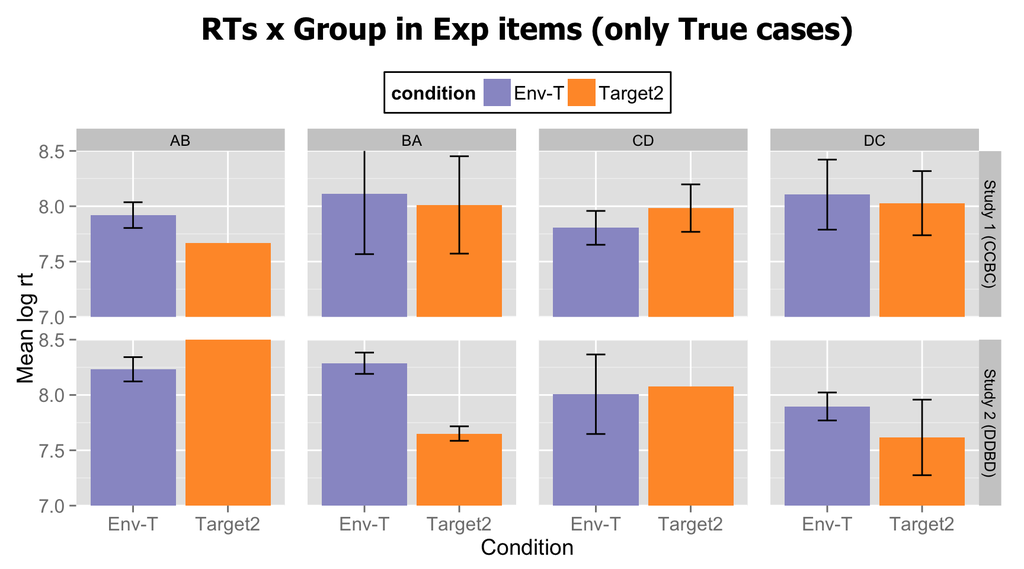

### Stats

*Global model*

```r
#I am taking out Target 1 because they are Baselines
mydata <- subset(Exp_Items, condition!='Target1')

#coding the interactions as factors
mydata$interaction<-contrasts(mydata$condition)[mydata$condition]*
contrasts(mydata$study)[mydata$study]

#### main model
m1 <- lmer(log_rt~condition+study+interaction+(1+condition|subject), mydata, REML=FALSE)
summary(m1)

#NOTE: I am not sure here how to code groups (I have to?)
```

*1. Main effect of condition in BOTH experiments*

```r
m0 <-  lmer(log_rt~study+interaction+(1+condition|subject), mydata, REML=FALSE)
summary(anova(m1,m0))
```

*2. Main effect of experiments*

```r
m0 <-  lmer(log_rt~condition+interaction+(1+condition|subject), mydata, REML=FALSE)
summary(anova(m1,m0))
```

*3. Interaction*

```r
m0 <-  lmer(log_rt~condition+study+(1+condition|subject), mydata, REML=FALSE)
summary(anova(m1,m0))
```

**If there is an interaction, I repeat step (1) for each experiment.**